# IODS course project

# About the project

**Introduction to Open Data Science 2018** is a cource that theaches you basics of Open Data, Open Science and Data Science. It is a open online cource, so you can attend “any time and any where” as long as you return your homeworks on time.

Have fun!

A link to my Github [repository](https://github.com/raimohaikari/IODS-project)

Load the packages:

```r
library(dplyr)

library(ggplot2)
library(gridExtra)
library(GGally)
```

# Regression and model validation

## Part 1

Data comes from survey where participants were asked questions to find out how different factors affect how well they perform in their statistics course.

Load the data:

```r
rm(list = ls()) # Clear the memory

url = "http://s3.amazonaws.com/assets.datacamp.com/production/course_2218/datasets/learning2014.txt"
lrn14 <- read.table(url, sep=",", header=TRUE)
```

Print general overview:

```r
str(lrn14)
```

```
## 'data.frame':    166 obs. of  7 variables:
##  $ gender  : Factor w/ 2 levels "F","M": 1 2 1 2 2 1 2 1 2 1 ...
##  $ age     : int  53 55 49 53 49 38 50 37 37 42 ...
##  $ attitude: num  3.7 3.1 2.5 3.5 3.7 3.8 3.5 2.9 3.8 2.1 ...
##  $ deep    : num  3.58 2.92 3.5 3.5 3.67 ...
##  $ stra    : num  3.38 2.75 3.62 3.12 3.62 ...
##  $ surf    : num  2.58 3.17 2.25 2.25 2.83 ...
##  $ points  : int  25 12 24 10 22 21 21 31 24 26 ...
```

There are:

- 166 observations of 7 variables
- one factor variable: Gender
- two discrete varibles: age and points
- four continous variables: attitude, deep, stra and suft

Deep, surf and stra are combination variables, that summarise questions related to deep, surface and strategic learning.

## Part 2

### Graphical overview

I will use ggpairs -function to show graphical overview of the data. I will comment graph later when i go through variables.

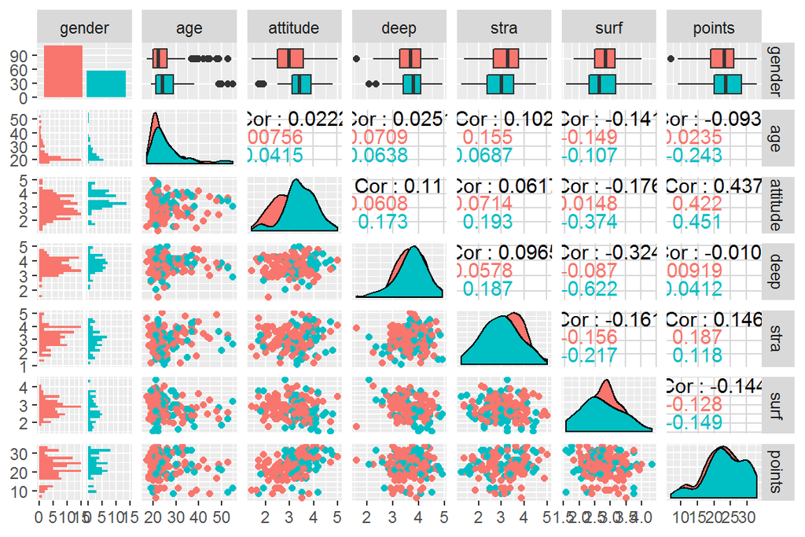

```r
p <- ggpairs(lrn14,
             mapping = aes(col = gender),
             lower = list(combo = wrap("facethist", bins = 20)))

p
```

### Summaries of the data

##### Gender

- There are 110 females and 56 males.
- Judging by the graphical overview men seem to be little older and have better attitude towards statistics.
- Female students have better points in questions related to strategic learning
- Female and male students have about same median points

```r
summary(lrn14$gender)
```

```
##   F   M
## 110  56
```

##### Age

- Distibution of age is right skewed in both groups (male, female).
- Majority of participants are about 20 years old
- Male age has slight negative correlation with points

```r
summary(lrn14$age)
```

```
##    Min. 1st Qu.  Median    Mean 3rd Qu.    Max.
##   17.00   21.00   22.00   25.51   27.00   55.00
```

##### Attitude

Lets take closer look of attitude distribution.

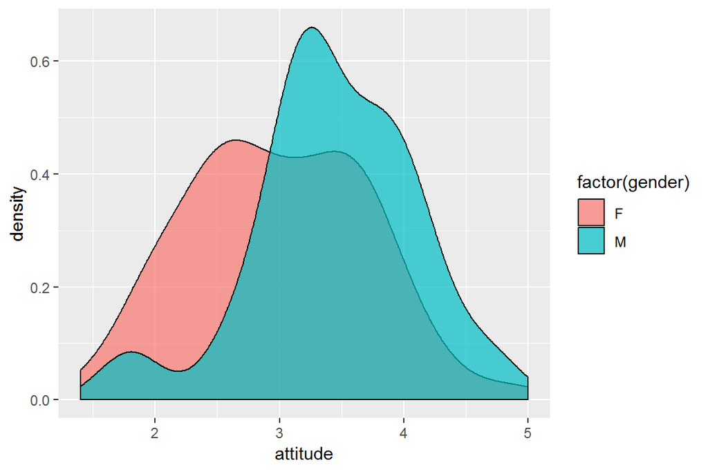

```r
ggplot(lrn14, aes(attitude)) + geom_density(aes(fill=factor(gender)), alpha=0.7)
```

- female students attitude distribution is near normal.
- male students attitude is little bit left skewed, that is majority of male students have higher points in attitude related questions.
- main thing about the general overview plot is that both sex have moderate correlation between attitude and points
- males have also moderate correlation between attitude and surface learning

```r
summary(lrn14$attitude)
```

```
##    Min. 1st Qu.  Median    Mean 3rd Qu.    Max.
##   1.400   2.600   3.200   3.143   3.700   5.000
```

##### Deep

- Distribution is left skewed. (Majority of students got more points than arithmetical mean value 2.5)

```r
summary(lrn14$deep)
```

```
##    Min. 1st Qu.  Median    Mean 3rd Qu.    Max.
##   1.583   3.333   3.667   3.680   4.083   4.917
```

##### Stra

- Distribution of points related to strategic learning is near normal.
- Female studens tend to have little bit better points

```r
summary(lrn14$stra)
```

```
##    Min. 1st Qu.  Median    Mean 3rd Qu.    Max.
##   1.250   2.625   3.188   3.121   3.625   5.000
```

##### Surf

Lets take a closer look of distribution of surface related questions:

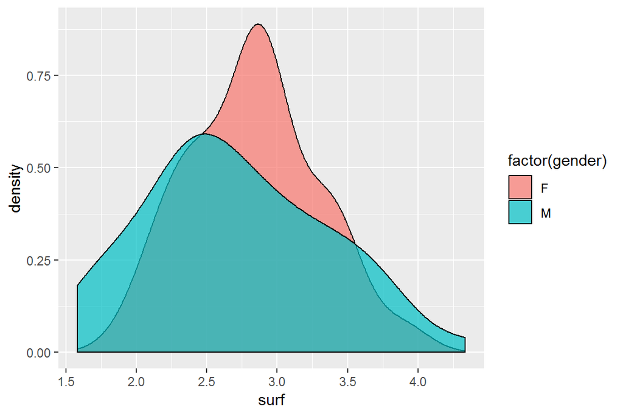

```r
ggplot(lrn14, aes(surf)) + geom_density(aes(fill=factor(gender)), alpha=0.7)
```

- female students distribution is near normal
- male studens range is wider and their distribution is little bit right skewed.
- female sudents got higher points in this category

```r
summary(lrn14$surf)
```

```
##    Min. 1st Qu.  Median    Mean 3rd Qu.    Max.
##   1.583   2.417   2.833   2.787   3.167   4.333
```

##### Points

Distribution is left skewed, which means that students in general got good grades (better than aritmetical distribution.)

```r
summary(lrn14$points)
```

```
##    Min. 1st Qu.  Median    Mean 3rd Qu.    Max.
##    7.00   19.00   23.00   22.72   27.75   33.00
```

## Part 3

Before i’ll fit my model. I will try to explain what is shown in the summary.

1. First there is the summary of residuals. Residuals are the difference of true values and values predicted by the model.
2. In Coefficients section there list of variables (used in model) and how they affect to the model. Each attribute has a p-value, which is a statistical assesment of validity. We are using sample to estimate population behaviour. Null hypothesis is that variable doesn’t have effect to the model in population level and coefficient should be zero. When we fit the regression line, we get some value for each variable. Variables p-Value tell us what is the probability to have that value even though value should be zero. Small p-value means that result wasn’t coincidence and that parameter is valid.
3. Finally there are figures that describe model and estimate its trustworthiness.

No we are ready to build our model.

Judging by the correlations displayed in general overview plot none of the attributes has strong correlation with points.

```r
model_one <- lm(points ~ attitude + surf + stra, data = lrn14)

summary(model_one)
```

```
##
## Call:
## lm(formula = points ~ attitude + surf + stra, data = lrn14)
##
## Residuals:
##      Min       1Q   Median       3Q      Max
## -17.1550  -3.4346   0.5156   3.6401  10.8952
##
## Coefficients:
##             Estimate Std. Error t value Pr(>|t|)
## (Intercept)  11.0171     3.6837   2.991  0.00322 **
## attitude      3.3952     0.5741   5.913 1.93e-08 ***
## surf         -0.5861     0.8014  -0.731  0.46563
## stra          0.8531     0.5416   1.575  0.11716
## ---
## Signif. codes:  0 '***' 0.001 '**' 0.01 '*' 0.05 '.' 0.1 ' ' 1
##
## Residual standard error: 5.296 on 162 degrees of freedom
## Multiple R-squared:  0.2074, Adjusted R-squared:  0.1927
## F-statistic: 14.13 on 3 and 162 DF,  p-value: 3.156e-08
```

In my first model there are two coefficients that don’t meet my p-value criteria. I’ll drop surf-values of my model and try again:

```r
model_two <- lm(points ~ attitude  + stra, data = lrn14)

summary(model_two)
```

```
##
## Call:
## lm(formula = points ~ attitude + stra, data = lrn14)
##
## Residuals:
##      Min       1Q   Median       3Q      Max
## -17.6436  -3.3113   0.5575   3.7928  10.9295
##
## Coefficients:
##             Estimate Std. Error t value Pr(>|t|)
## (Intercept)   8.9729     2.3959   3.745  0.00025 ***
## attitude      3.4658     0.5652   6.132 6.31e-09 ***
## stra          0.9137     0.5345   1.709  0.08927 .
## ---
## Signif. codes:  0 '***' 0.001 '**' 0.01 '*' 0.05 '.' 0.1 ' ' 1
##
## Residual standard error: 5.289 on 163 degrees of freedom
## Multiple R-squared:  0.2048, Adjusted R-squared:  0.1951
## F-statistic: 20.99 on 2 and 163 DF,  p-value: 7.734e-09
```

Stra doesn’t meet the p-value criteria so i drop if off.

```r
model_three <- lm(points ~ attitude, data = lrn14)

summary(model_three)
```

```
##
## Call:
## lm(formula = points ~ attitude, data = lrn14)
##
## Residuals:
##      Min       1Q   Median       3Q      Max
## -16.9763  -3.2119   0.4339   4.1534  10.6645
##
## Coefficients:
##             Estimate Std. Error t value Pr(>|t|)
## (Intercept)  11.6372     1.8303   6.358 1.95e-09 ***
## attitude      3.5255     0.5674   6.214 4.12e-09 ***
## ---
## Signif. codes:  0 '***' 0.001 '**' 0.01 '*' 0.05 '.' 0.1 ' ' 1
##
## Residual standard error: 5.32 on 164 degrees of freedom
## Multiple R-squared:  0.1906, Adjusted R-squared:  0.1856
## F-statistic: 38.61 on 1 and 164 DF,  p-value: 4.119e-09
```

Now “all” coffeficients are statistically valid.

## Part 4

##### Summary

My final model has two coefficients: intercept and attitude.

intercept

- value is about 11.6. It tells the point where regression line intercpets y-axis.
- student whose attitude is 0 is expect to have 11.6 points

attitude

- value is about 3.5, which means that one point rise in attitude means 3.5 higher points.

##### Multiple R-squared

Multiple R-squared is a value that gives overall assesment how well model is doing. It tells the porpotion of variance explained by the model. Near one values are preferable.

## Part 5

Diagnostic plots are used to test that assuptions of linear regression are met.

##### Residuals vs. Fitted

Residuals vs. Fitted plot is used to assure that phenomenon we are trying to model is linear.

Residuals should be equally spread around the x-axis of the plot and there shouldn’t be any noticeable patterns.

My model doesn’t capture the true essense of phenomenon because, plot identifies three outlier valus, that is rows 145, 56 and 35.

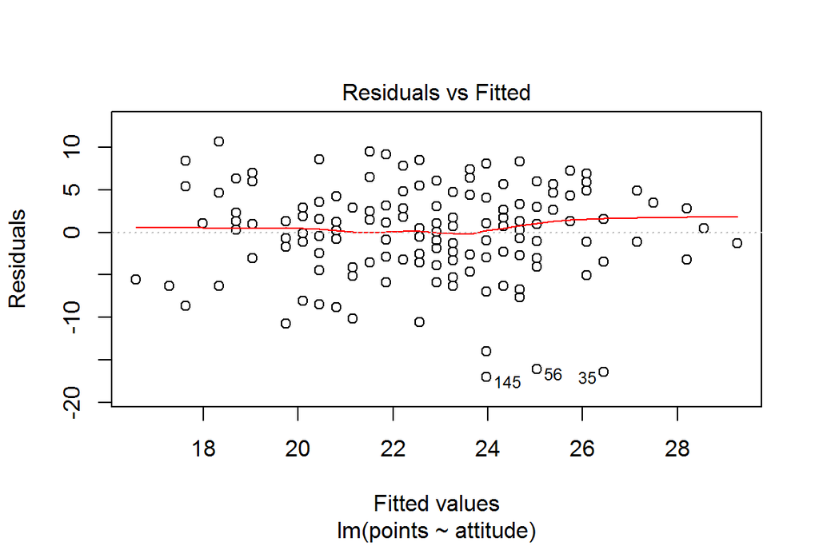

```r
plot(model_three, which = 1)
```

##### Normal QQ-plot

Residuals shoud be normally distributed. QQ-Plot is used to test that assumption. Residuals should line well with the diagonal axis.

In my model there are problems in both ends of theoretical line. Which means that the model doesn’t explain phenomeon “totally”“, three are some”too big residuals"

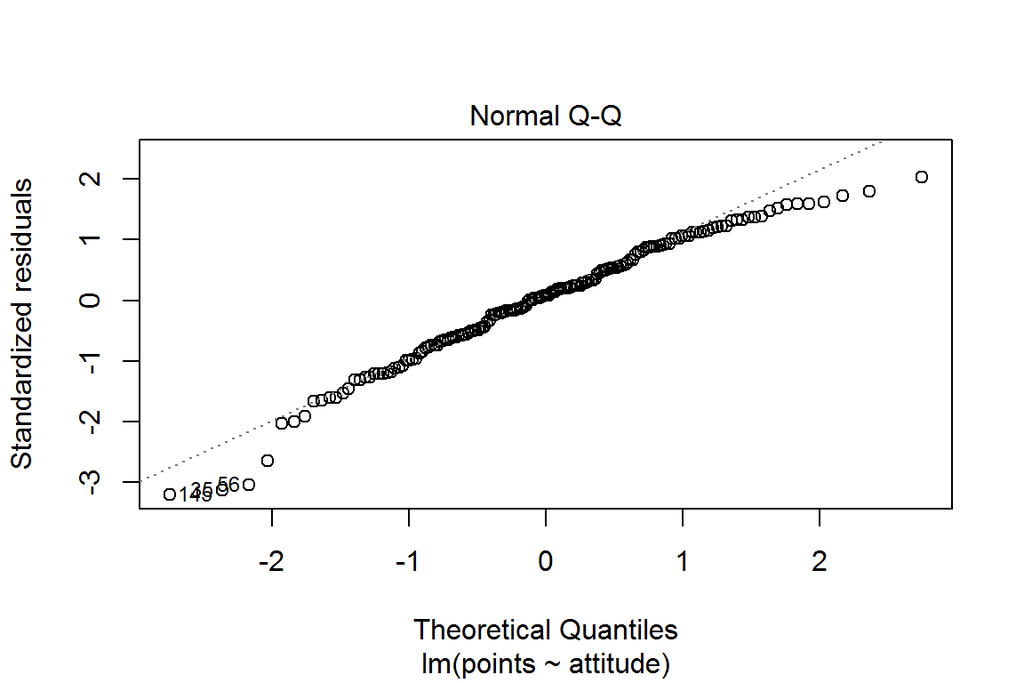

```r
plot(model_three, which = 2)
```

##### Residuals vs Leverage

This plot helps us to see if there are observations that distort our model. Those observations are outliers that don’t fit with the trend of the data. If there are such observations, removing those will improve models accuracy.

And once again there are few obsevations that distort my model.

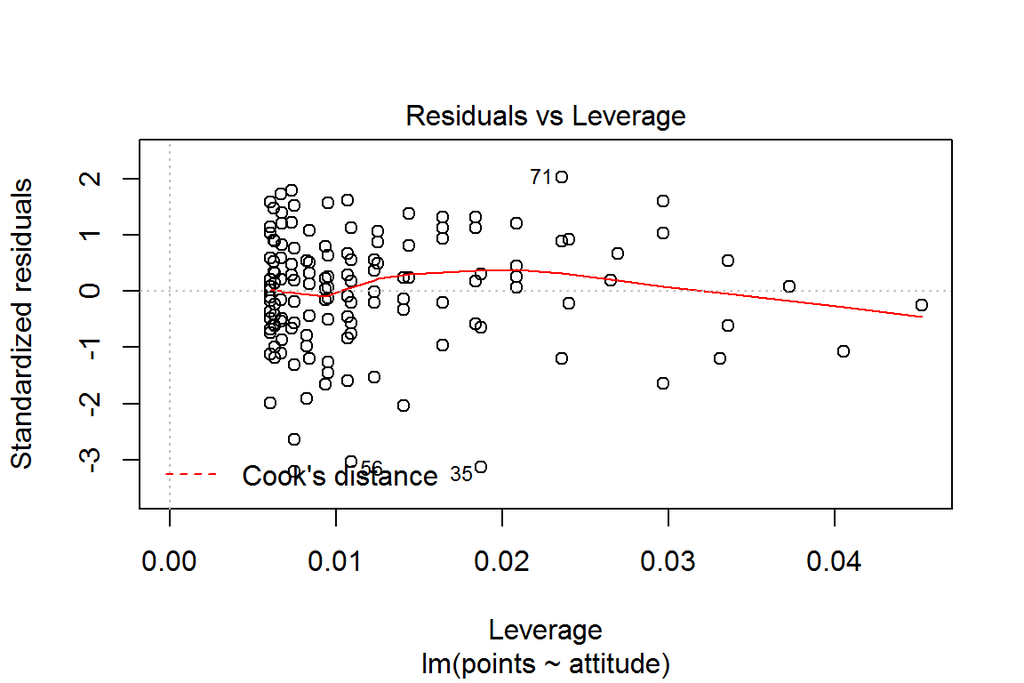

```r
plot(model_three, which = 5)
```

Load the packages:

```r
library(dplyr)
library(tidyr)

library(ggplot2)
library(GGally)

library(caret)
```

# Logistic regression

##### Overview of the data

Original data has information on student performances in two Portuguese schools. The data attributes include information how students are doing in school and their backgrounds. There are two datasets, one focuses on Mathematics studies (mat) and other Portuguese language (por) studies.

In data wrangling part of this weeks assignment datafiles were combined so that combination data has information on those students who were present in both of the disctinct datasets (por and mat).

Analysis part of this weeks assignment focuses on building a model that predicts probability of students high alcohol use. So two additional columns were added:

- one that calculates mean of student weekly and weekend alcohol use
- one that classifies students average alcohol use either high or low based on average consumption.

[Link](https://archive.ics.uci.edu/ml/datasets/Student+Performance) to the original data.

Load the data:

```r
rm(list = ls()) # Clear the memory

url = "http://s3.amazonaws.com/assets.datacamp.com/production/course_2218/datasets/alc.txt"

alc <- read.table(url, sep=",", header=TRUE)
```

##### Data in nutshell

```r
dim(alc)

# How many factor variables
print(paste("There are ", sum(sapply(alc, is.factor)), " factor variables", sep=""))

# How many numeric variables
print(paste("There are ", sum(sapply(alc, is.numeric)), " numeric variables", sep=""))

# How many logical variables
print(paste("There are ", sum(sapply(alc, is.logical)), " logical variables", sep=""))
```

[output not shown]

There are:

- 382 observations of 35 variables
- 17 factor variables
- 17 numeric variables
- 1 logical variable

##### Select the variables

Our task is to choose 4 variables and study their relationship between high/low alcohol consumption.

One thing to concider when choosing explanatory variables is that there has to be variance in variable values. If majority of observations have same value, variable has limited prediction power.

So I will print a graph that can be use as an aid to check the distribution of variables.

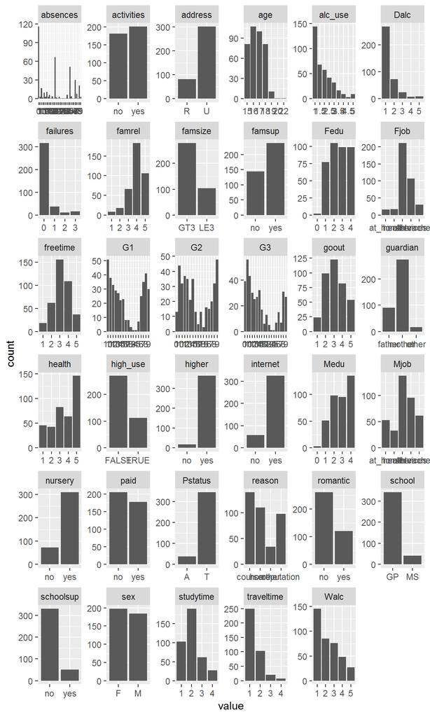

```r
gather(alc) %>%
  ggplot(aes(value)) +
  geom_bar() +
  facet_wrap("key", scales = "free")
```

Based on data description, distribution plot, intuition and prejudice I choose following 4 variables:

- sex: student’s sex (binary: ‘F’ - female or ‘M’ - male)
- absences: number of school absences (numeric: from 0 to 93)
- romantic: with a romantic relationship (binary: yes or no)
- goout: going out with friends (numeric: from 1 - very low to 5 - very high)

My hypothesis is that:

- Male students drink more than female students
- Students who drink have more absences
- If student has a boy or girlfriend she/he won’t be as tempted to go drinking
- Students that spend more time with their friend propably attend parties more often.

And by combing these risk factors we are able to identify abusers and contact local authorities!

##### Overview of chosen variables

Summaries of the chosen variables.

##### sex

- It is a factor variable
- number of males and females is almost equal
- according to the probability table & bar graph male students drink more

```r
summary(alc$sex)
```

```
##   F   M
## 198 184
```

```r
prop.table(
  table(alc$sex, alc$high_use), margin = 1
)
```

```
##
##         FALSE      TRUE
##   F 0.7929293 0.2070707
##   M 0.6141304 0.3858696
```

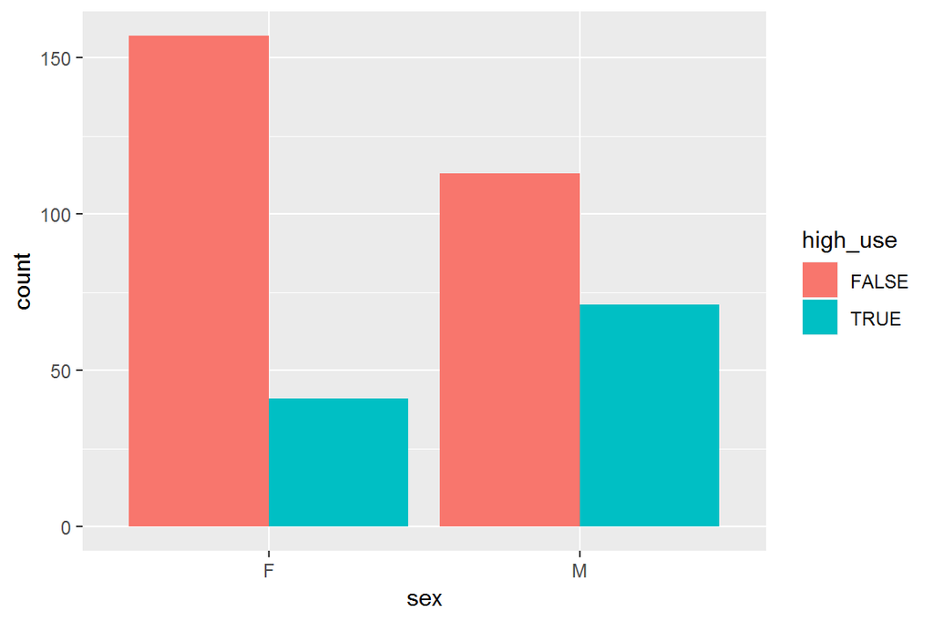

```r
ggplot(alc, aes(sex)) +
  geom_bar(aes(fill = high_use), stat="count", position=position_dodge())
```

##### absences

- It is a numerical variable
- It has a right skewed distribution, majority of students have zero of only a couple absences
- because there are lot’s of distinct values, and in higher end values become sparse, it’s difficult to form an opinion of variables prediction power
- but according to the distribution plot it seems that students who have lot of absences more likely belong to the high use group

```r
summary(alc$absences)
```

```
##    Min. 1st Qu.  Median    Mean 3rd Qu.    Max.
##   0.000   0.000   3.000   5.319   8.000  75.000
```

```r
sort(unique(alc$absences))
```

```
##  [1]  0  1  2  3  4  5  6  7  8  9 10 11 12 13 14 15 16 17 18 19 20 21 22
## [24] 23 24 25 26 28 30 54 56 75
```

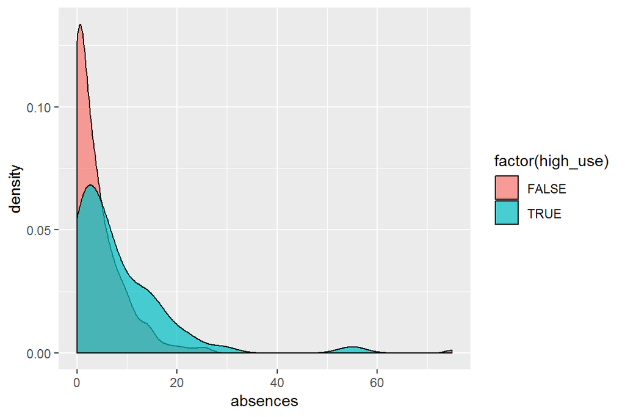

```r
ggplot(alc, aes(absences)) +
  geom_density(aes(fill=factor(high_use)), alpha=0.7)
```

```r
# table(alc$absences, alc$high_use)
# prop.table(table(alc$absences, alc$high_use), margin = 1)
```

##### romantic

- factor variable
- amount of singles is about two times higher than students who are dating
- judging by the probability table & bar chart, romantic relationship doesn’t seem to affect the probabitity of high alcohol use

```r
summary(alc$romantic)
```

```
##  no yes
## 261 121
```

```r
prop.table(
  table(alc$romantic, alc$high_use), margin = 1
)
```

```
##
##           FALSE      TRUE
##   no  0.6973180 0.3026820
##   yes 0.7272727 0.2727273
```

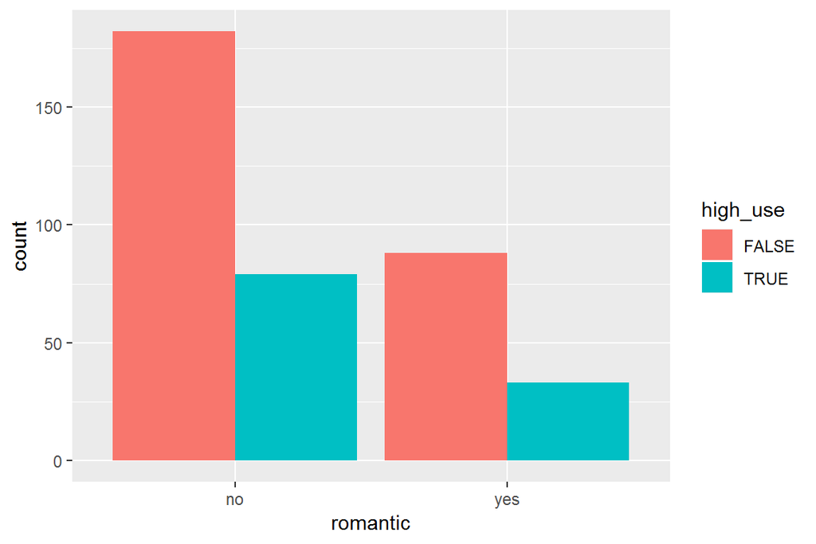

```r
ggplot(alc, aes(romantic)) +
  geom_bar(aes(fill = high_use), stat="count", position=position_dodge())
```

##### goout

- numeric variable
- has distinct values: 1,2,3,4,5
- students who go out 4 or 5 times a week seem to have a risk of high alcohol use

```r
summary(alc$goout)
```

```
##    Min. 1st Qu.  Median    Mean 3rd Qu.    Max.
##   1.000   2.000   3.000   3.113   4.000   5.000
```

```r
unique(alc$goout)
```

```
## [1] 4 3 2 1 5
```

```r
prop.table(
  table(alc$goout,alc$high_use), margin = 1
)
```

```
##
##         FALSE      TRUE
##   1 0.8750000 0.1250000
##   2 0.8484848 0.1515152
##   3 0.8130081 0.1869919
##   4 0.5243902 0.4756098
##   5 0.4074074 0.5925926
```

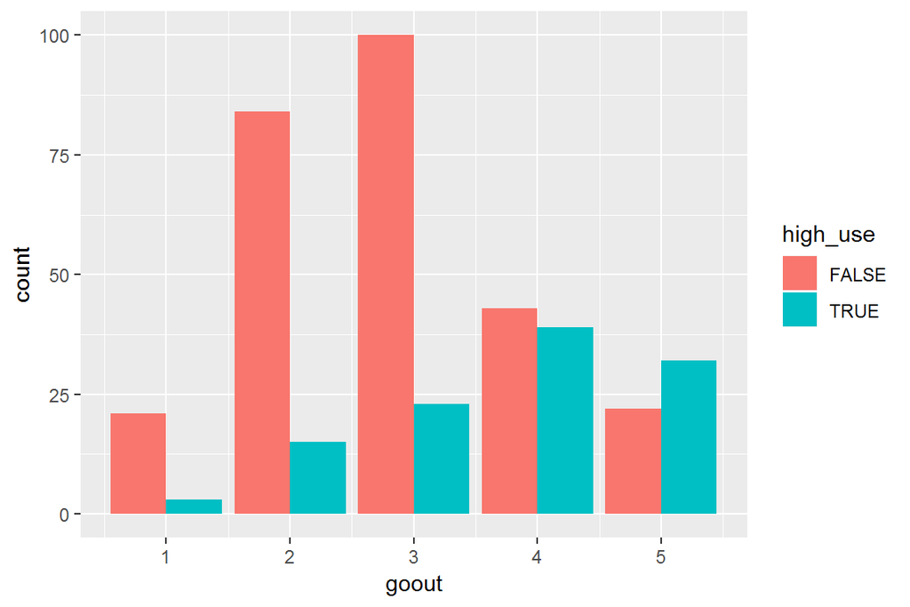

```r
ggplot(alc, aes(goout)) +
  geom_bar(aes(fill = high_use), stat="count", position=position_dodge())
```

##### High use

```r
(hu = table(alc$high_use))
```

```
##
## FALSE  TRUE
##   270   112
```

```r
(hu[1] / sum(hu))
```

```
##     FALSE
## 0.7068063
```

##### Conclusion

Based on variable exploration it seems that:

- two variables are useful (sex and goout)
- one variable might have some use (absenses)
- one variable has no prediction power (romantic).

So my selection doesn’t look as good as i hope it would, but let’s see what happens.

### Logistic regression model

Let’s fit logistic regression model with chosen values:

```r
m <- glm(high_use ~ sex + absences + romantic + goout, data = alc, family = "binomial")
```

##### Summary of the model

In the first line you can see the formula.

After that there is a summary of the residuals: range, first and third quantiles and median. It would be good if values lie near zero. My model seems to have some kind of problems, because median is below zero and positive values have larger spread than negative values have.

Then there is a list of coefficients. When model is calculating estimation, coefficients are used in a following way:

1. Intercept coeffient (-4.18334) is taken as an starting point
2. sexM
- if student is male 0.98673 is added to the sum
- if student is female, sum remains the same
3. absences
- each absense adds 0.06805 to the sum
4. romanticyes
- if student is in a romantic relationship 0.25962 is subtracted from the sum
- otherwise sum remais the same
5. goout
- each “goout” adds 0.74848 to the sum

Result of sum is the logarithm of division probability of high use vs probability of low use; in other words log of the odds. And when you know log of odds, you can calculate the probality of positive event, which in this case is high alcohol use:

- if e.g log of the odds is: -0.7811263
- R’s exp -function returns: 0.45789, which is the odds ratio
- by solving equation: p / 1 - p = 0.45789 you get the probability of the event, which is 0.3140772.

With each coefficient there is also p-value, which tells the probability whether that coefficient is statistically valid. Typically p-value has to be less than 0.05. Three out of my four variables have p-value less than 0.05. Romanticyes doesn’t meet that criteria, so i should rule it out and retrain the model.

```r
summary(m)
```

```
##
## Call:
## glm(formula = high_use ~ sex + absences + romantic + goout, family = "binomial",
##     data = alc)
##
## Deviance Residuals:
##     Min       1Q   Median       3Q      Max
## -1.8042  -0.8053  -0.5187   0.7613   2.5267
##
## Coefficients:
##             Estimate Std. Error z value Pr(>|z|)
## (Intercept) -4.18334    0.48783  -8.575  < 2e-16 ***
## sexM         0.98673    0.25831   3.820 0.000134 ***
## absences     0.06805    0.01718   3.961 7.48e-05 ***
## romanticyes -0.25962    0.27988  -0.928 0.353613
## goout        0.74848    0.12047   6.213 5.20e-10 ***
## ---
## Signif. codes:  0 '***' 0.001 '**' 0.01 '*' 0.05 '.' 0.1 ' ' 1
##
## (Dispersion parameter for binomial family taken to be 1)
##
##     Null deviance: 462.21  on 381  degrees of freedom
## Residual deviance: 380.57  on 377  degrees of freedom
## AIC: 390.57
##
## Number of Fisher Scoring iterations: 4
```

##### coefficients of the model:

Lets review the coefficients. Each coefficient by itself is also logarithm of the odds ratio. which tells: “If it is up to that variable, how much does the probability of event change”. If variables odds ratio is above 1 that variable increases the total probabilitys of event. There are three such variables in my model: sexM, absences and goout.

An analogy is that variables are switches. Starting point is that all the switches are off. Value of intercept tells the log of the odds between “high use” and “low use” in that situation. In my model value of (Intercept) is 0.01524751, which means that there is a low probability that random student is a high user.

sexM has an odds ratio of 2.68245830, which means male students have about 2.7 higher risk of being high user when compared to the female students.

In absences each absence increases 1.07 times the risk of being high user.

In goout one step increase in value increases 2.1 times the risk of being high user.

```r
coef(m)
```

```
## (Intercept)        sexM    absences romanticyes       goout
## -4.18333918  0.98673365  0.06804636 -0.25962009  0.74848369
```

```r
# compute odds ratios (OR)
OR <- coef(m) %>% exp

# compute confidence intervals (CI)
CI <- exp(confint(m))
# print out the odds ratios with their confidence intervals
cbind(OR, CI)
```

```
##                     OR       2.5 %     97.5 %
## (Intercept) 0.01524751 0.005613121 0.03816271
## sexM        2.68245830 1.627115237 4.48953680
## absences    1.07041493 1.037289407 1.11057958
## romanticyes 0.77134457 0.441126075 1.32568965
## goout       2.11379243 1.679217348 2.69577960
```

##### Prediction

Let’s see how my model is doing. I use it to predict training set values and the compare results with actual values.

But for starters i will retrain my model without romantic variable, so that all the predictors will be statistically significant. Then i analyse results with caret -packages confusionMatrix -function, which will print detailed overview of results.

This time most interesting parts of report are:

- Accuracy, which is the percentage of correct predictions
- No Information Rate, which is the percentage of dominant class. I you just predict that all instances belong that class, you would get that success rate.

Jugding by report, my model had some success, at least it was able to beat the no information rate.

```r
# retrain the model
m <- glm(high_use ~ sex + absences + goout, data = alc, family = "binomial")
# summary(m)

# setup new data frame, which has both actual values and predicion
df <- alc %>%
  mutate(predProbs = predict(m, type = "response")) %>%
  mutate(pred = ifelse(predProbs > 0.5, TRUE, FALSE)) %>%
  select(high_use, pred, predProbs)
# 2x2 cross tabulation of predictions versus actual values
xtab <- table(df$pred, df$high_use)

# summary of results
print(confusionMatrix(xtab[2:1,2:1]))
```

```
## Confusion Matrix and Statistics
##
##
##         TRUE FALSE
##   TRUE    46    15
##   FALSE   66   255
##
##                Accuracy : 0.788
##                  95% CI : (0.7435, 0.8279)
##     No Information Rate : 0.7068
##     P-Value [Acc > NIR] : 0.0002098
##
##                   Kappa : 0.4098
##  Mcnemar's Test P-Value : 2.767e-08
##
##             Sensitivity : 0.4107
##             Specificity : 0.9444
##          Pos Pred Value : 0.7541
##          Neg Pred Value : 0.7944
##              Prevalence : 0.2932
##          Detection Rate : 0.1204
##    Detection Prevalence : 0.1597
##       Balanced Accuracy : 0.6776
##
##        'Positive' Class : TRUE
##
```

##### 10-fold cross-validation

I will retrain my model, but this time i will use caret-packages cross-validation.

I will proceed with different strategy which was used in DataCamp. I use cross-validation in training phase.

General idea is that dataset is divided into 10 subgroups. Training process is a loop that runs 10 times, each time 9 groubs are used for training and one is left out. So each group will be left out once. Final model is combination of those 10 submodels.

Advantage of this strategy is that in this way we get more general view of the phenomenon compared to situation where whole training set is used at once. Prediction accuracy for training set might decreace but, if we would have to use on model to totally new dataset, cross-validated model should be more accurate than “original model”, because that model is fine tuned for the training set.

```r
# backup of the original data
alc_backup <- alc

# encode factor variables to binary varibles
dummies_model <- dummyVars(~.,  data = alc)
alc  <- data.frame(predict(dummies_model, newdata = alc))

# select the variables used in training
alc <- alc[,c("sex.M","absences","goout")]
alc$high_use <- alc_backup$high_use
alc$high_use <- as.factor(alc$high_use)

# create cross-validation sets
set.seed(8520)
indx <- createFolds(alc$high_use, returnTrain = TRUE)

# setup traincontrol -object
ctrl <- trainControl(method = "cv",
                     index = indx,
                     savePredictions = TRUE)

# train model using cross-validation
cvModel <- train(x = alc[,c("sex.M","absences","goout")],
                 y = alc$high_use,
                 method = "glm",
                 trControl = ctrl)
```

Let see what happens we use our cross-validated model for prediction.

```r
# Predict
cvModelPred <- predict(cvModel, type = "prob")
colnames(cvModelPred) <- c('No','Yes')


df <- df %>%
  mutate(cvPredProbs = cvModelPred$Yes) %>%
  mutate(cvPred = ifelse(cvPredProbs > 0.5, TRUE, FALSE)) %>%
  select(high_use, pred, predProbs, cvPred, cvPredProbs)

sum(df$pred != df$cvPred) # 0 - models have same predictions
```

```
## [1] 0
```

```r
sum(df$predProbs != df$cvPredProbs)
```

```
## [1] 0
```

Hmm… results seem to be exactly same. Even the probabilities match. As I stated earlier, i was expecting that cross-validated model would do worse in predicting training set.

# Clustering and classification

## Part I

##### Custom funtions

**cor.test** calculates correlation p-values

Parameters are: - mar: dataset

**positiveCorrelation** and **negativeCorrelation** select one variable and then seek if any of other variables have high positive or negative correlation with selected variable.

Parameters are: - M: precalculated correlation matrix - varname: selected variable - cLimit: limit of high correlation

```r
rm(list=ls()) # Clear memory

cor.mtest <- function(mat, ...) {
    mat <- as.matrix(mat)
    n <- ncol(mat)
    p.mat<- matrix(NA, n, n)
    diag(p.mat) <- 0
    for (i in 1:(n - 1)) {
        for (j in (i + 1):n) {
            tmp <- cor.test(mat[, i], mat[, j], ...)
            p.mat[i, j] <- p.mat[j, i] <- tmp$p.value
        }
    }
  colnames(p.mat) <- rownames(p.mat) <- colnames(mat)
  p.mat
}


negativeCorrelation <- function(M, varname, cLimit = 0.6){
  names(
    which(
      apply(
        as.matrix(sort(M[!rownames(M) %in% varname,varname], decreasing = TRUE)),
        1,
        function(x) x < -1 * cLimit
        )
      )
  )
}

positiveCorrelation <- function(M, varname, cLimit = 0.6){
  names(
    which(
      apply(
        as.matrix(sort(M[!rownames(M) %in% varname,varname], decreasing = TRUE)),
        1,
        function(x) x > cLimit
        )
      )
  )
}
```

Load the packages:

```r
library(MASS)
library(dplyr)
library(ggplot2)

library(caret)
# library(Rtsne)
library(ggalt)
library(GGally)

library(corrplot)
```

This weeks exercise uses Boston dataset which is a part of MASS -package. Dataset contains information of Housing Values in Suburbs of Boston. It’s well known dataset which had been used a lot in different machine learning purposes, escpecially in testing regression models.

Because Dataset is a part of R package, you can find more information about it by typing **?Boston** in R command line.

Read the data:

```r
data("Boston")

options(scipen=999) # disable scientific notation
```

Data has:

- 14 numeric variables
- 2 of variables are discrete [chas and rad]
- 12 of variables are continous
- 506 observations

```r
dim(Boston)
```

```
## [1] 506  14
```

```r
str(Boston)
```

```
## 'data.frame':    506 obs. of  14 variables:
##  $ crim   : num  0.00632 0.02731 0.02729 0.03237 0.06905 ...
##  $ zn     : num  18 0 0 0 0 0 12.5 12.5 12.5 12.5 ...
##  $ indus  : num  2.31 7.07 7.07 2.18 2.18 2.18 7.87 7.87 7.87 7.87 ...
##  $ chas   : int  0 0 0 0 0 0 0 0 0 0 ...
##  $ nox    : num  0.538 0.469 0.469 0.458 0.458 0.458 0.524 0.524 0.524 0.524 ...
##  $ rm     : num  6.58 6.42 7.18 7 7.15 ...
##  $ age    : num  65.2 78.9 61.1 45.8 54.2 58.7 66.6 96.1 100 85.9 ...
##  $ dis    : num  4.09 4.97 4.97 6.06 6.06 ...
##  $ rad    : int  1 2 2 3 3 3 5 5 5 5 ...
##  $ tax    : num  296 242 242 222 222 222 311 311 311 311 ...
##  $ ptratio: num  15.3 17.8 17.8 18.7 18.7 18.7 15.2 15.2 15.2 15.2 ...
##  $ black  : num  397 397 393 395 397 ...
##  $ lstat  : num  4.98 9.14 4.03 2.94 5.33 ...
##  $ medv   : num  24 21.6 34.7 33.4 36.2 28.7 22.9 27.1 16.5 18.9 ...
```

```r
sum(sapply(Boston, function(x){is.double(x)})) # number of continous  variables
```

```
## [1] 12
```

```r
sum(sapply(Boston, function(x){!is.double(x)})) # number of discrete variables
```

```
## [1] 2
```

## Part II

Let’s see what our data is made of. I will go through the variables one by one. But first i will calculate correlation matrix and present correlogram.

##### Correlations

I’ll use [custom function](http://www.sthda.com/english/wiki/visualize-correlation-matrix-using-correlogram) which calculates correlation p-Values. And in the correlogram i drop the correlations that aren’t statistically valid.

Correlogram is organized so that positive correlations lie near diagonal axis.

Thing that cathes eye is that most of the correlations between chas and other variables seem to be statistically insicnificat. And there are lots of dark circles which means that variables correlate with each other.

When i go through individual variables i will each time print variables that have either positive or negative correlation with active variable.

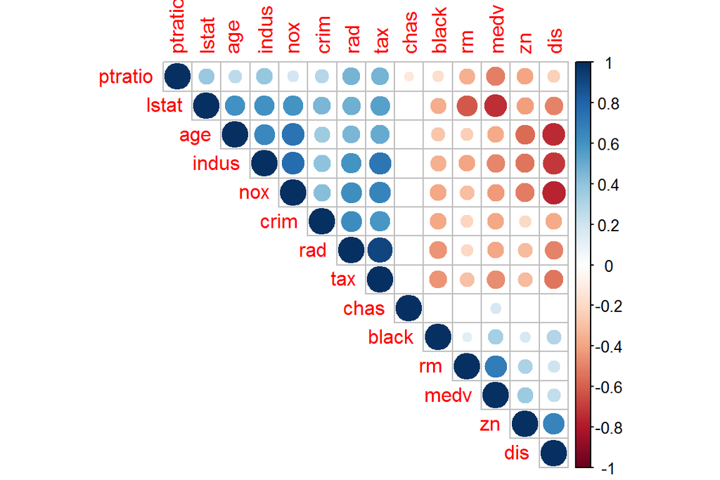

```r
# correlation matrix
cMat <- cor(Boston,use="pairwise.complete.obs")

# matrix of the p-value of the correlation
p.mat <- cor.mtest(Boston)

# Leave blank on no significant coefficient
corrplot(cMat, type="upper", order="hclust",
         p.mat = p.mat, sig.level = 0.01, insig = "blank")
```

If correlation is **below -0.6** or **above 0.6** I consider it to be strong.

```r
cLimit = 0.6
```

##### crim

- **per capita crime rate by town**
- right skewed distribution
- 70 % of observations are below 2
- highest decile consist of values that really stand out of the overall distribution
- in overall towns seem to be safe, but there are some bad neighborhoods
- crim has a high positive correlation with variable rad (0.6255051)

```r
summary(Boston$crim)
```

```
##     Min.  1st Qu.   Median     Mean  3rd Qu.     Max.
##  0.00632  0.08204  0.25651  3.61352  3.67708 88.97620
```

```r
quantile(Boston$crim, probs = seq(0, 1, 0.1))
```

```
##        0%       10%       20%       30%       40%       50%       60%
##  0.006320  0.038195  0.064170  0.099245  0.150380  0.256510  0.550070
##       70%       80%       90%      100%
##  1.728440  5.581070 10.753000 88.976200
```

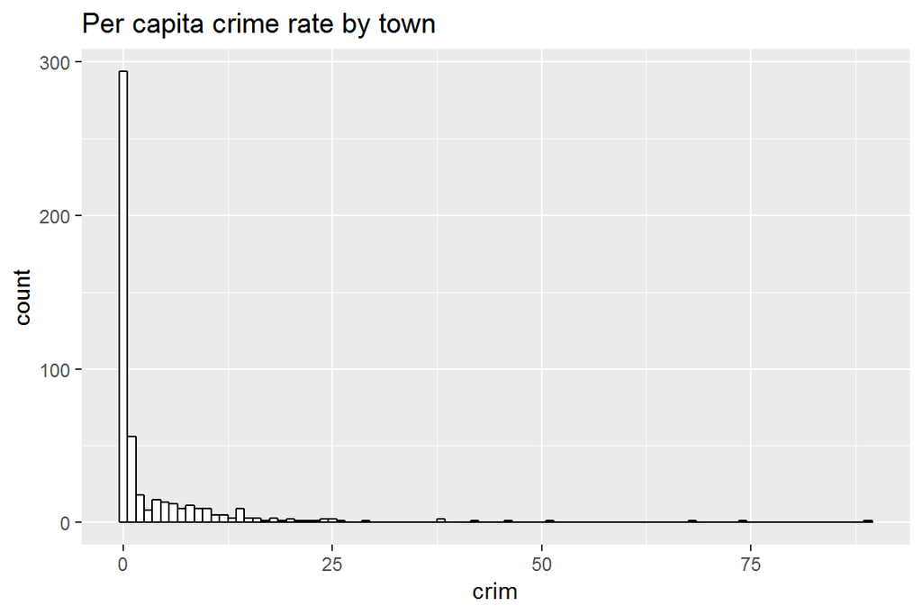

```r
ggplot(Boston, aes(crim)) +
  geom_histogram(binwidth=1,fill="white",colour="black") +
  labs(title="Per capita crime rate by town")
```

```r
(p = positiveCorrelation(cMat, 'crim', cLimit))
```

```
## [1] "rad"
```

```r
cMat['crim',p]
```

```
## [1] 0.6255051
```

```r
(p = negativeCorrelation(cMat, 'crim', cLimit))
```

```
## character(0)
```

```r
# cMat['crim',p]
```

##### zn

```r
summary(Boston$zn)
```

```
##    Min. 1st Qu.  Median    Mean 3rd Qu.    Max.
##    0.00    0.00    0.00   11.36   12.50  100.00
```

```r
nrow(Boston[which(Boston$zn == 0),])/nrow(Boston)
```

```
## [1] 0.7351779
```

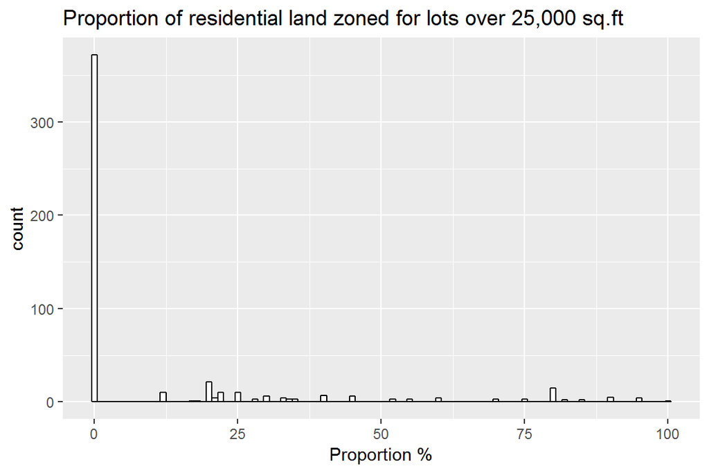

```r
ggplot(Boston, aes(zn)) +
  geom_histogram(binwidth=1,fill="white",colour="black") +
  labs(title="Proportion of residential land zoned for lots over 25,000 sq.ft",
       x = "Proportion %")
```

```r
(p = positiveCorrelation(cMat, 'zn', cLimit))
```

```
## [1] "dis"
```

```r
cMat['zn',p]
```

```
## [1] 0.6644082
```

```r
(p = negativeCorrelation(cMat, 'zn', cLimit))
```

```
## character(0)
```

```r
# cMat['zn',p]
```

##### indus

- **proportion of non-retail business acres per town**
- histogram seems a little bit polarised. Maby the right tail of histogram represents manufacturing areas?
- indus has a high positive correlation with variables nox (0,76), tax (0,72), age (0,64) and lstat (0,6)
- indus has a high negative correlation with variable dis (-0.71)

Note. Histogram is combined with density plot!

```r
summary(Boston$indus)
```

```
##    Min. 1st Qu.  Median    Mean 3rd Qu.    Max.
##    0.46    5.19    9.69   11.14   18.10   27.74
```

```r
quantile(Boston$indus, probs = seq(0, 1, 0.1))
```

```
##    0%   10%   20%   30%   40%   50%   60%   70%   80%   90%  100%
##  0.46  2.91  4.39  5.96  7.38  9.69 12.83 18.10 18.10 19.58 27.74
```

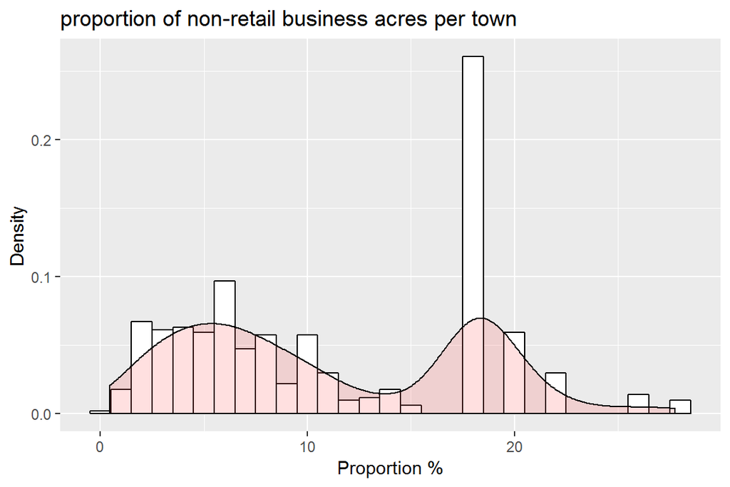

```r
ggplot(Boston, aes(x=indus)) +
    geom_histogram(aes(y=..density..),
                   binwidth=1,
                   colour="black", fill="white") +
    geom_density(alpha=.2, fill="#FF6666")  +
    labs(title="proportion of non-retail business acres per town",
       y = "Density",
       x = "Proportion %")
```

```r
p = positiveCorrelation(cMat, 'indus', cLimit)
cMat['indus',p]
```

```
##       nox       tax       age     lstat
## 0.7636514 0.7207602 0.6447785 0.6037997
```

```r
(p = negativeCorrelation(cMat, 'indus', cLimit))
```

```
## [1] "dis"
```

```r
cMat['indus',p]
```

```
## [1] -0.708027
```

##### chas

```r
summary(Boston$chas)
```

```
##    Min. 1st Qu.  Median    Mean 3rd Qu.    Max.
## 0.00000 0.00000 0.00000 0.06917 0.00000 1.00000
```

```r
prop.table(table(Boston$chas))
```

```
##
##          0          1
## 0.93083004 0.06916996
```

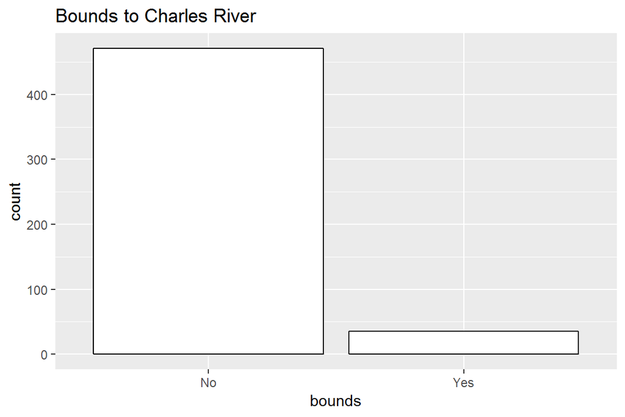

```r
Boston %>%
  mutate(bounds = ifelse(chas,'Yes','No')) %>%
  ggplot(., aes(bounds)) +
  geom_bar(fill="white",colour="black") +
  labs(title="Bounds to Charles River")
```

```r
(p = positiveCorrelation(cMat, 'chas', cLimit))
```

```
## character(0)
```

```r
# cMat['chas',p]

(p = negativeCorrelation(cMat, 'chas', cLimit))
```

```
## character(0)
```

```r
# cMat['chas',p]
```

##### nox

- **nitrogen oxides concentration (parts per 10 million)**
- right skewed distribution with “bumps”
- nox has a high positive correlation with variables indus (0.76), age (0.73), tax (0,67) and rad (0.61)
- nox has a high nevative correlation with variable dis (-0.77)

Note. Histogram is combined with density plot!

```r
summary(Boston$nox)
```

```
##    Min. 1st Qu.  Median    Mean 3rd Qu.    Max.
##  0.3850  0.4490  0.5380  0.5547  0.6240  0.8710
```

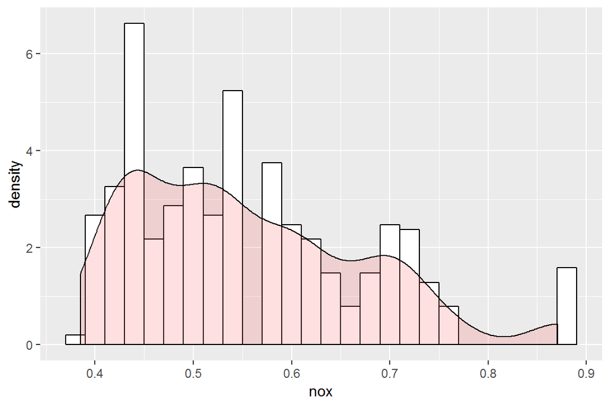

```r
ggplot(Boston, aes(x=nox)) +
    geom_histogram(aes(y=..density..),
                   binwidth=.02,
                   colour="black", fill="white") +
    geom_density(alpha=.2, fill="#FF6666")
```

```r
p = positiveCorrelation(cMat, 'nox', cLimit)
cMat['nox',p]
```

```
##     indus       age       tax       rad
## 0.7636514 0.7314701 0.6680232 0.6114406
```

```r
(p = negativeCorrelation(cMat, 'nox', cLimit))
```

```
## [1] "dis"
```

```r
cMat['nox',p]
```

```
## [1] -0.7692301
```

##### rm

- average number of rooms per dwelling
- distribution is near normal
- typical value is 6
- rh has high positive correlation with variable medv (0.7)
- rh has high negative correlation with variable lstat (-0.61)

Note. Histogram is combined with density plot!

```r
summary(Boston$rm)
```

```
##    Min. 1st Qu.  Median    Mean 3rd Qu.    Max.
##   3.561   5.886   6.208   6.285   6.623   8.780
```

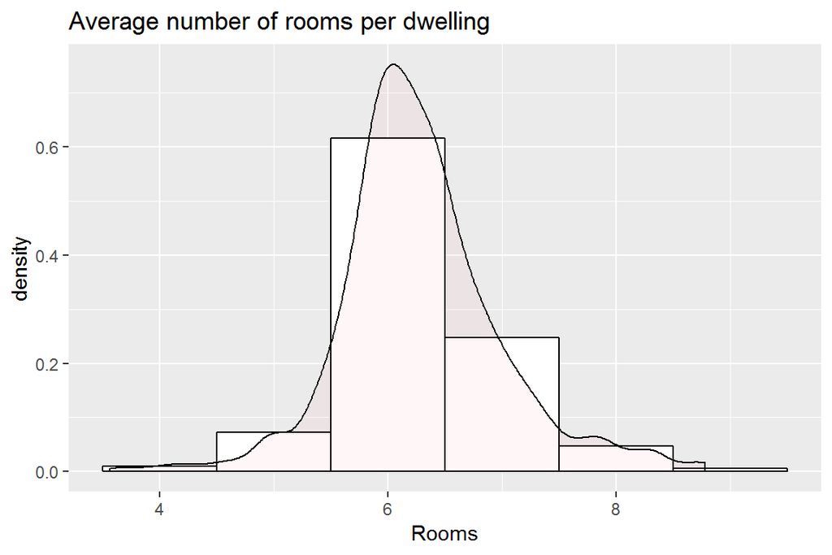

```r
ggplot(Boston, aes(x=rm)) +
    geom_histogram(aes(y=..density..),
                   binwidth=1,
                   colour="black", fill="white") +
    geom_density(alpha=.05, fill="#FF6666") +
    labs(title="Average number of rooms per dwelling",
       x = "Rooms")
```

```r
(p = positiveCorrelation(cMat, 'rm', cLimit))
```

```
## [1] "medv"
```

```r
cMat['rm',p]
```

```
## [1] 0.6953599
```

```r
(p = negativeCorrelation(cMat, 'rm', cLimit))
```

```
## [1] "lstat"
```

```r
cMat['rm',p]
```

```
## [1] -0.6138083
```

##### age

- proportion of owner-occupied units built prior to 1940.
- dataset was published 1978, so variable tells the porpotion of at least fourty years old houses
- mildly left skewed distribution that has “strong growth” in last decile
- age has a high positive correlation with variables nox (0.73), indus (0.64) and lstat (0.60)
- age has a high negative correlation with variable dis (-0.75)

```r
summary(Boston$age)
```

```
##    Min. 1st Qu.  Median    Mean 3rd Qu.    Max.
##    2.90   45.02   77.50   68.57   94.08  100.00
```

```r
quantile(Boston$age, probs = seq(0, 1, 0.1))
```

```
##     0%    10%    20%    30%    40%    50%    60%    70%    80%    90%
##   2.90  26.95  37.80  52.40  65.40  77.50  85.90  91.80  95.60  98.80
##   100%
## 100.00
```

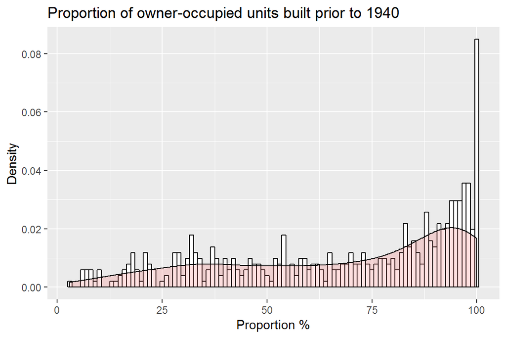

```r
ggplot(Boston, aes(x=age)) +
    geom_histogram(aes(y=..density..),
                   binwidth=1,
                   colour="black", fill="white") +
    geom_density(alpha=.2, fill="#FF6666") +
    labs(title="Proportion of owner-occupied units built prior to 1940",
        x = "Proportion %",
        y = "Density")
```

```r
p = positiveCorrelation(cMat, 'age', cLimit)
cMat['age',p]
```

```
##       nox     indus     lstat
## 0.7314701 0.6447785 0.6023385
```

```r
(p = negativeCorrelation(cMat, 'age', cLimit))
```

```
## [1] "dis"
```

```r
cMat['age',p]
```

```
## [1] -0.7478805
```

##### dis

- weighted mean of distances to five Boston employment centres.
- right skewed distribution that is most of areas are near employment centre
- dis has a high correlation with variable zn (0.66)
- dis has a high correlation with variables indus (-0.71), age (-0.75) and nox (-0.77)

Note. Histogram is combined with density plot!

```r
summary(Boston$dis)
```

```
##    Min. 1st Qu.  Median    Mean 3rd Qu.    Max.
##   1.130   2.100   3.207   3.795   5.188  12.127
```

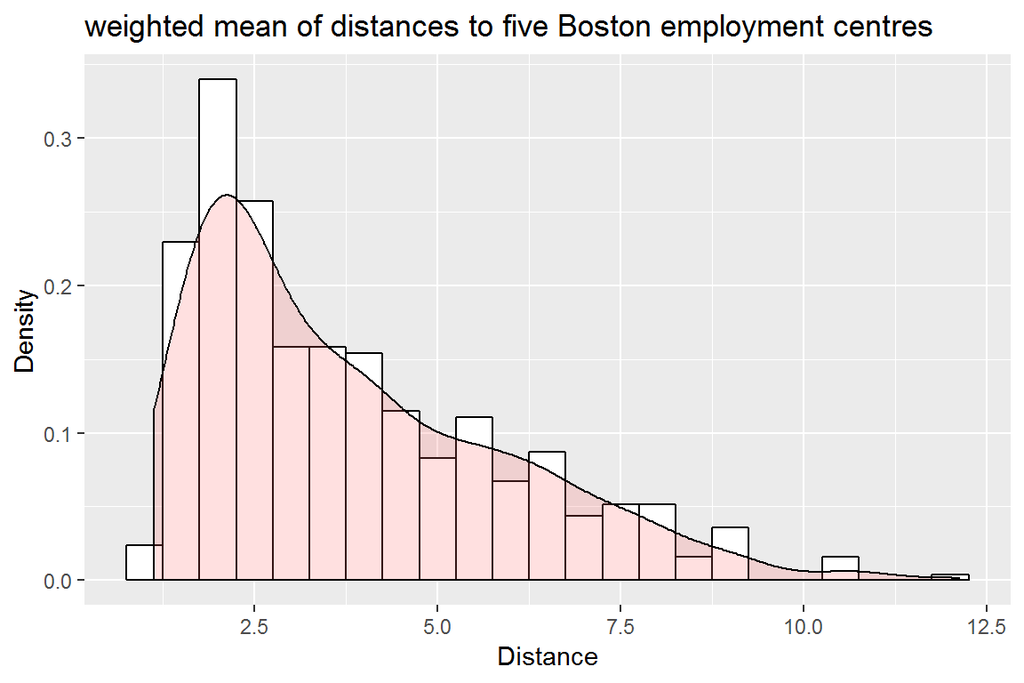

```r
ggplot(Boston, aes(x=dis)) +
    geom_histogram(aes(y=..density..),
                   binwidth=0.5,
                   colour="black", fill="white") +
    geom_density(alpha=.2, fill="#FF6666") +
    labs(title="weighted mean of distances to five Boston employment centres",
        x = "Distance",
        y = "Density")
```

```r
(p = positiveCorrelation(cMat, 'dis', cLimit))
```

```
## [1] "zn"
```

```r
cMat['dis',p]
```

```
## [1] 0.6644082
```

```r
p = negativeCorrelation(cMat, 'dis', cLimit)
cMat['dis',p]
```

```
##      indus        age        nox
## -0.7080270 -0.7478805 -0.7692301
```

##### rad

- index of accessibility to radial highways
- discrete
- polarised
- rad has a high correlation with variables tax (0.91), crim (0.63) and nox (0.61)

Note. Histogram is combined with density plot!

```r
summary(Boston$rad)
```

```
##    Min. 1st Qu.  Median    Mean 3rd Qu.    Max.
##   1.000   4.000   5.000   9.549  24.000  24.000
```

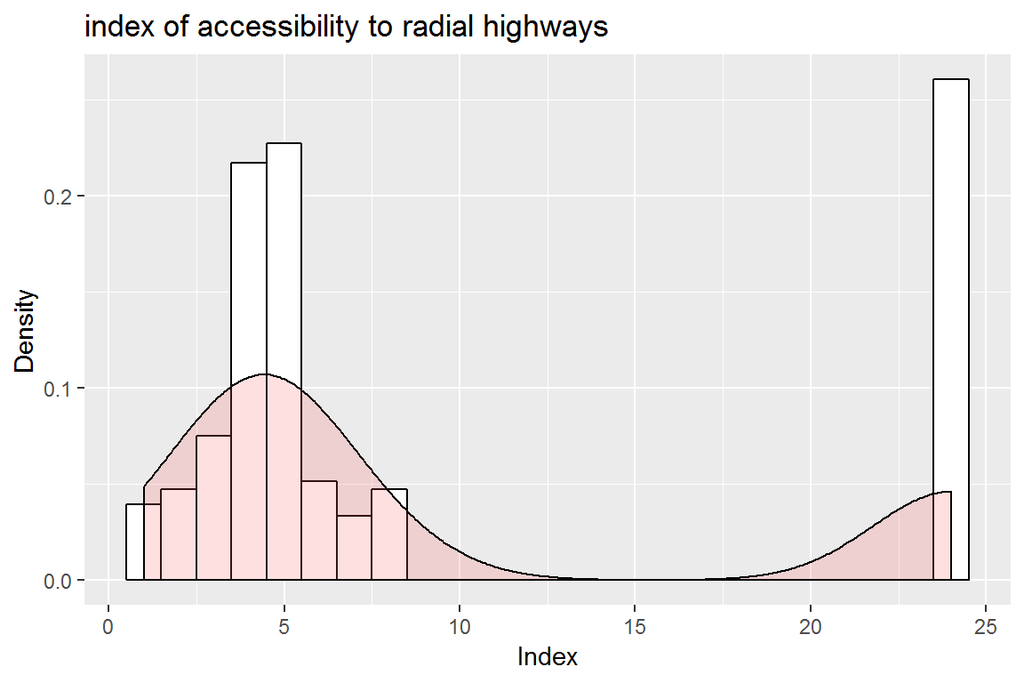

```r
ggplot(Boston, aes(x=rad)) +
    geom_histogram(aes(y=..density..),
                   binwidth=1,
                   colour="black", fill="white") +
    geom_density(alpha=.2, fill="#FF6666") +
    labs(title="index of accessibility to radial highways",
        x = "Index",
        y = "Density")
```

```r
p = positiveCorrelation(cMat, 'rad', cLimit)
cMat['rad',p]
```

```
##       tax      crim       nox
## 0.9102282 0.6255051 0.6114406
```

```r
(p = negativeCorrelation(cMat, 'rad', cLimit))
```

```
## character(0)
```